# Final excerise for Open Data Science -course

Markus Selin, markus.selin@helsinki.fi

The 8th of March, 2017

# Final assignment for course on open data science

This web page is inteded for publishing the data handling and analysis related to final learning assignment on course introduction to open data science. The data wrangling file related to the final assignment may be found [here](https://github.com/MSatHY/IODS-final/blob/master/data/wrangling.R). The repository and the web page are hosted at [GitHub](https://github.com/). During the course we also prepared [a learning diary](https://msathy.github.io/IODS-project/).

# Abstract

The work here presents linear regression analysis results on data combined from kunnat.net and sotkanet.fi. Finninsh municipalities are changing size over time. Following the trends over long times is tricky, however, since several fusions of municipalties have taken place. The data here was handled to prevent the influence of the fusions on the results. High average time of higher education per capita in the municipality was found to be key to detect percentually fast growing municipalities. A pretty good linear regression model could be archived by combining the key variable with 3 other variables: population size, percentual amount of crowded households and dependancy ratio. In the last chapter, the model diagnostic plots are presented and results discussed as well as analytic goals for future are set.

# Initial data gathering and wrangling

I desided immediately to focus on Finnish open data. I got interested to study the Finnish muncipalities and their population changes. Therefore, I spend a lot of time to read two Excel-files (“Kuntajaot ja asukasluvut 2000-2016.xls” ja “Kuntien pinta-alat ja asukastiheydet 2016”, please check the reference “Lähde” below) from [Kunnat.net](http://www.kunnat.net/fi/Sivut/default.aspx) into R-data. The gathered (and handled) population information contains 313 observations (the muncipalities) and 17 variables (the population during years 2000-2016, checked at the start of the year). The files also reported fusions of muncipalities occuring during the given time frame. Since I was not interested to see the direct effects of the fusions on population numbers, I desided calculate the population numbers of the current muncipalities as if they had existed since 2000. Two of the fusions were difficult to handle. Temmes was joined between 3 muncipalities; however, I desided to ingnore the parts joined to Liminka and Rantsila as the main part was joined into Tyrnävä. Population of Längelmäki was complitely ingnored in this analysis, although approx. 64 % of the population lived in the part that joined into Jämsä and 36 % in the part joined into Orivesi ([source](http://w3.verkkouutiset.fi/arkisto/politiikka/73820.html)).

Lähde: Kuntien tietotekniikkakartoitus 2013, Suomen Kuntaliitto ry. Lisenssillä Creative Commons Nimeä 4.0 Kansainvälinen (CC BY 4.0).

Below you can also find an example plot that visualizes an interesting exception in data: a part of Sipoo was fused with Helsinki (Sipoo still remains as an individual municipality). The summary of the data (see below) shows that more 3/4 of the Finnish muncipalities are smaller than the calculated average size of Finnish municipality. The smallest municipality (Sottunga) has not changed in size very much whereas the largerst municipality (Helsinki) has noticably grown. The histogram (see below) shows the distribution in graphical form. It is evident that there are only very few muncipalities with over 30,000 people in Findland. As most of the muncipalities seemed to have changed very little, I got intrested to study the ones that had changed more. In the [data wrangling file](https://github.com/MSatHY/IODS-final/blob/master/data/wrangling.R) I also read the other Excel file and wrangle the information about the areas (dry land, sweet water, and salt water) in the muncipalities (summary of that data may be found below). Some muncipalities have huge bodies of water while medians of aquous areas are quite small. Over 3/4 of the muncipalities have less than 1000 km<sup>2</sup> land area. The smallest municipality is Kauniainen and the largest is Inari. More technical data on muncipalities may be found from [avoindata.fi](https://www.avoindata.fi/fi) web site (check [this](https://www.avoindata.fi/data/fi/dataset/kunnat) for example). However, I would like to search for more living oriented data to explain the changes in population sizes.

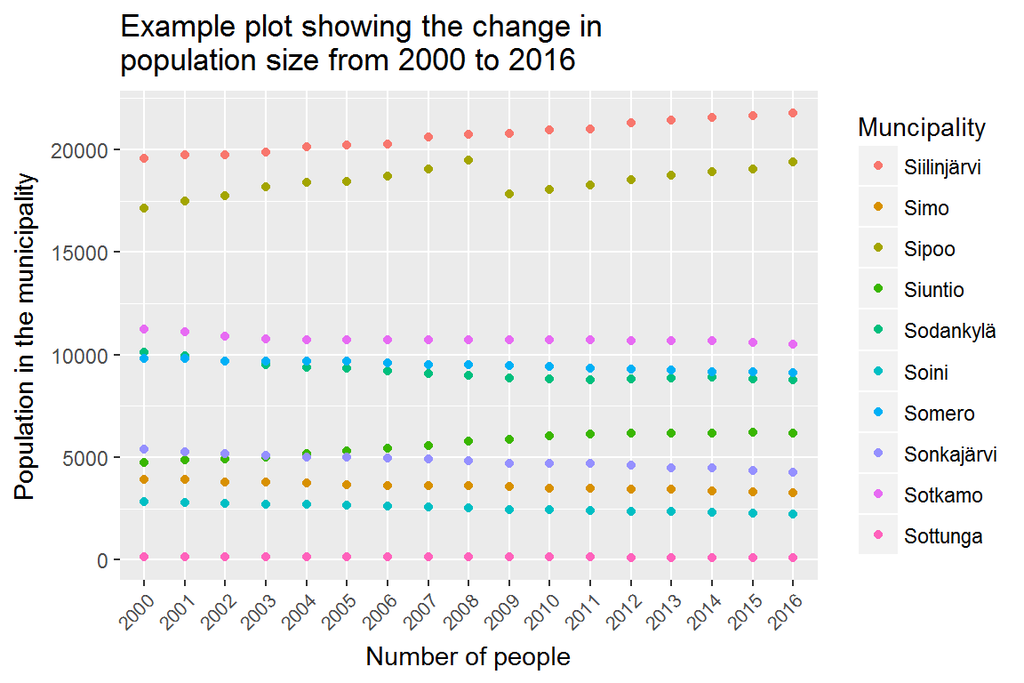

```r
# Example plot
test <- population
start_row <- 251
end_row <- start_row+9
colnames(test) <- 2000:2016
test2 <- test[start_row:end_row,]
test2[,(ncol(test2)+1)] <- rownames(test2)
colnames(test2)[ncol(test2)] <- "Muncipality"
test3 <- test2 %>% gather("Year", "Population", 1:(ncol(test2)-1) )
ggplot(test3, aes(x = Year, y = Population, col = Muncipality)) + geom_point() + theme(axis.text.x = element_text(angle = 45, hjust = 1, size = 8)) + ggtitle("Example plot showing the change in\npopulation size from 2000 to 2016") + xlab("Number of people") + ylab("Population in the municipality")
```

```r
test <- population
colnames(test) <- 2000:2016
summary(test)
```

```
##       2000             2001             2002             2003
##  Min.   :   122   Min.   :   129   Min.   :   128   Min.   :   132
##  1st Qu.:  3288   1st Qu.:  3274   1st Qu.:  3259   1st Qu.:  3206
##  Median :  6635   Median :  6583   Median :  6486   Median :  6403
##  Mean   : 16518   Mean   : 16550   Mean   : 16594   Mean   : 16630
##  3rd Qu.: 13474   3rd Qu.: 13283   3rd Qu.: 13280   3rd Qu.: 13684
##  Max.   :551123   Max.   :555474   Max.   :559718   Max.   :559716
##       2004             2005             2006             2007
##  Min.   :   134   Min.   :   131   Min.   :   127   Min.   :   120
##  1st Qu.:  3175   1st Qu.:  3148   1st Qu.:  3107   1st Qu.:  3065
##  Median :  6340   Median :  6285   Median :  6227   Median :  6215
##  Mean   : 16673   Mean   : 16727   Mean   : 16788   Mean   : 16859
##  3rd Qu.: 13879   3rd Qu.: 13982   3rd Qu.: 13803   3rd Qu.: 13767
##  Max.   :559330   Max.   :559046   Max.   :560905   Max.   :564521
##       2008             2009             2010             2011
##  Min.   :   116   Min.   :   115   Min.   :   125   Min.   :   119
##  1st Qu.:  3056   1st Qu.:  3033   1st Qu.:  3020   1st Qu.:  2998
##  Median :  6131   Median :  6081   Median :  6024   Median :  6104
##  Mean   : 16935   Mean   : 17017   Mean   : 17097   Mean   : 17173
##  3rd Qu.: 13702   3rd Qu.: 13803   3rd Qu.: 13895   3rd Qu.: 14067
##  Max.   :568531   Max.   :576632   Max.   :583350   Max.   :588549
##       2012             2013             2014             2015
##  Min.   :   103   Min.   :   101   Min.   :   100   Min.   :   101
##  1st Qu.:  2996   1st Qu.:  2950   1st Qu.:  2925   1st Qu.:  2901
##  Median :  6061   Median :  5983   Median :  5995   Median :  6045
##  Mean   : 17256   Mean   : 17338   Mean   : 17416   Mean   : 17482
##  3rd Qu.: 14191   3rd Qu.: 14245   3rd Qu.: 14422   3rd Qu.: 14681
##  Max.   :595384   Max.   :603968   Max.   :612664   Max.   :620715
##       2016
##  Min.   :    99
##  1st Qu.:  2894
##  Median :  6068
##  Mean   : 17531
##  3rd Qu.: 14609
##  Max.   :628208
```

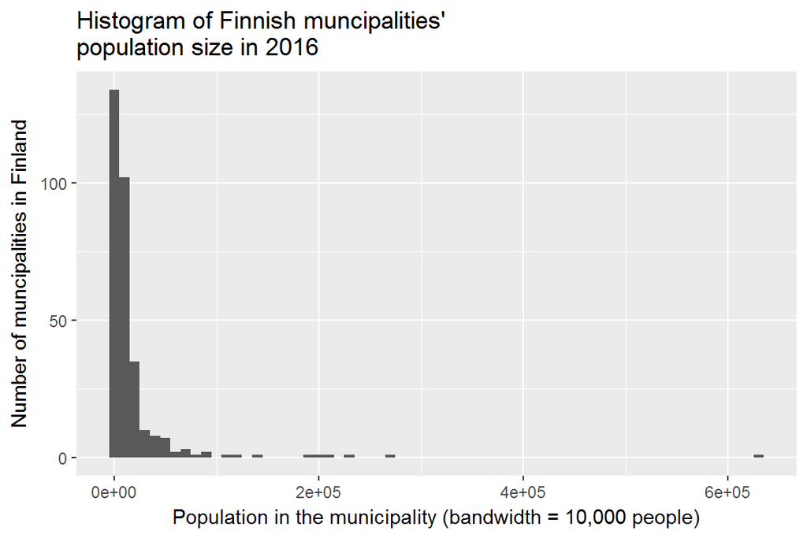

```r
test <- population
colnames(test)[ncol(test)] <- "Vuosi"
ggplot(test, aes(x = Vuosi)) + geom_histogram(binwidth = 10000) + ggtitle("Histogram of Finnish muncipalities'\npopulation size in 2016") + xlab("Population in the municipality (bandwidth = 10,000 people)") + ylab("Number of muncipalities in Finland")
```

```r
summary(areas)
```

```
##     land_km2        sweet_h2o_km2      salt_h2o_km2
##  Min.   :    5.89   Min.   :   0.00   Min.   :   0.0
##  1st Qu.:  300.46   1st Qu.:   5.40   1st Qu.:   0.0
##  Median :  543.17   Median :  36.58   Median :   0.0
##  Mean   :  970.93   Mean   : 110.36   Mean   : 167.6
##  3rd Qu.:  980.91   3rd Qu.: 146.55   3rd Qu.:   0.0
##  Max.   :15055.10   Max.   :2278.55   Max.   :4658.0
```

[figure not shown]

```r
test <- areas
ggplot(test, aes(x = land_km2)) + geom_histogram(binwidth = 250) + ggtitle("Histogram of Finnish muncipalities'\nland area in 2016") + xlab(expression(paste("Land area in the municipality (bandwidth = 25 km"^"2"*")"))) + ylab("Number of muncipalities in Finland")
```

# Gathering data to model percentual population change from 2000 to 2016

For the rest of the exercise I focused on the municipalities most grown (20) and most diminished (20). During the data wrangling step, I had accidentally written a code that caused it to miss the most grown munipality. Instead, 20 most grown municipalities omitting the most grown munipality were selected. The data gathering step included a manual web-site browsing and interface manipulation. The error should not influence the generalizability of the results very much. Omitting one municipality with missing information, information on the following places was collected:

```r
rownames(selected)
```

```
##  [1] "Espoo"       "Hyrynsalmi"  "Ilomantsi"   "Jomala"      "Juuka"
##  [6] "Kemijärvi"   "Kempele"     "Kirkkonummi" "Kivijärvi"   "Kontiolahti"
## [11] "Kyyjärvi"    "Lemland"     "Lempäälä"    "Luoto"       "Masku"
## [16] "Muurame"     "Mäntsälä"    "Nokia"       "Nurmijärvi"  "Oulu"
## [21] "Pello"       "Pirkkala"    "Pornainen"   "Posio"       "Puolanka"
## [26] "Puumala"     "Rautavaara"  "Rautjärvi"   "Ristijärvi"  "Rääkkylä"
## [31] "Salla"       "Savukoski"   "Siuntio"     "Suomussalmi" "Tyrnävä"
## [36] "Vaala"       "Valtimo"     "Vesilahti"   "Ylöjärvi"
```

The fusions of the muncipalities make it difficult to obtain relevant data from 2000 (the muncipalities do not exist in their current form). Therefore, I desided to find data from 2016 for modelling the percentual population change. From [Sotkanet.fi](https://www.sotkanet.fi/sotkanet/fi/index), I found information on social environment of people. The open data in sotkanet is (as I understood) provided by Finnish health agency [Terveyden ja Hyvinvoinnin laitos](https://www.thl.fi/fi/) with [Creative Commons Lisence](https://yhteistyotilat.fi/wiki08/display/THLKA/THL%3An+avoimen+datan+lisenssi+ja+vastuuvapauslauseke). I desided to calculate the percentual population change from 2000 to 2016 in each current Finnish municipality (calculated from the previous data which largely circumvents the effects of municipality fusions). Then I downloaded 2016 information on average education time per capita after the comprehensive schooling ([metadata](https://www.sotkanet.fi/sotkanet/fi/metadata/indicators/180)), number of persons outside working force per 100 workers, percentual amount of tightly packed households ([metadata](https://www.sotkanet.fi/sotkanet/fi/metadata/indicators/183)), amount of crimes against lives and health of individuals acknowledged by the police per 1000 people ([metadata](https://www.sotkanet.fi/sotkanet/fi/metadata/indicators/3113)), and amount of crimes against property acknowledged by the police per 1000 people ([metadata](https://www.sotkanet.fi/sotkanet/fi/metadata/indicators/3114)). The data provided by the user interface may be found using [this link](https://www.sotkanet.fi/sotkanet/fi/csv?indicator=szYKijcytPbyjzcEAA==&region=y65MTDZzNE62NtIzi09LyjHMskw1sTS1SE4zNTIzzDA0tTQBSlnEpxYmmSYVAQA=&year=sy4rAwA=&gender=t&abs=f&color=f&order=G). For some reason, the data on the number of persons outside working force per 100 workers was not included in the downloaded file. With a second try, I was able to [download a file](https://www.sotkanet.fi/sotkanet/fi/csv?indicator=szYKtjYJsTZJtnastM5wBAA=&region=y65MTDZzNE62NtIzi09LyjHMskw1sTS1SE4zNTIzzDA0tTQBSlnEpxYmmSYVAQA=&year=sy4rAwA=&gender=t&abs=f&color=f&order=G) with some variables from 2015 describing the working situation in the selected muncipalities. The variables are (all metadata in Finnish): percentage of income supported population ([metadata](https://www.sotkanet.fi/sotkanet/fi/metadata/indicators/493)), dependency ratio ([metadata](https://www.sotkanet.fi/sotkanet/fi/metadata/indicators/761)), percentage of population with low income in the muncipality ([metadata](https://www.sotkanet.fi/sotkanet/fi/metadata/indicators/3099)), and the total sum of labor market support (in thousands of euros) shares paid by the municipality ([metadata](https://www.sotkanet.fi/sotkanet/fi/metadata/indicators/4223)).

```r
summary(selected)
```

```
##      change          population        land_km2          lake_km2
##  Min.   :-32.252   Min.   :  1061   Min.   :  81.43   Min.   :  0.21
##  1st Qu.:-26.337   1st Qu.:  2599   1st Qu.: 278.87   1st Qu.: 19.70
##  Median : 23.843   Median :  5125   Median : 491.81   Median : 57.30
##  Mean   :  3.202   Mean   : 21165   Mean   :1273.79   Mean   :134.60
##  3rd Qu.: 30.079   3rd Qu.: 15946   3rd Qu.:1461.36   3rd Qu.:175.72
##  Max.   : 53.043   Max.   :269802   Max.   :6438.65   Max.   :586.83
##     sea_km2          density           education       tightness
##  Min.   :  0.00   Min.   :  0.1648   Min.   :206.0   Min.   : 5.200
##  1st Qu.:  0.00   1st Qu.:  2.1503   1st Qu.:245.0   1st Qu.: 6.950
##  Median :  0.00   Median : 13.8122   Median :306.0   Median : 9.000
##  Mean   : 94.95   Mean   : 55.5858   Mean   :313.3   Mean   : 8.962
##  3rd Qu.:  0.00   3rd Qu.: 45.8196   3rd Qu.:376.0   3rd Qu.: 9.900
##  Max.   :851.20   Max.   :864.1407   Max.   :468.0   Max.   :19.300
##     violence          crime       income_support     dependency
##  Min.   : 1.400   Min.   : 4.20   Min.   :  3.00   Min.   : 65.0
##  1st Qu.: 3.150   1st Qu.:13.00   1st Qu.: 43.50   1st Qu.: 87.5
##  Median : 4.600   Median :18.50   Median : 55.00   Median :107.0
##  Mean   : 4.728   Mean   :20.84   Mean   : 61.72   Mean   :102.1
##  3rd Qu.: 5.800   3rd Qu.:27.40   3rd Qu.: 82.00   3rd Qu.:120.0
##  Max.   :10.400   Max.   :53.50   Max.   :135.00   Max.   :134.0
##    low_income     labour_support
##  Min.   :  6.00   Min.   :  2.00
##  1st Qu.: 25.50   1st Qu.: 16.50
##  Median : 38.00   Median : 57.00
##  Mean   : 57.85   Mean   : 61.51
##  3rd Qu.:100.50   3rd Qu.:101.50
##  Max.   :136.00   Max.   :140.00
```

[figure not shown]

```r
p <- ggpairs(selected, upper=NULL, lower = list(combo = wrap("facethist", bins = 20)))
p + ggtitle("Histograms and pairwise scatter plots\nof the variables in the data")
```

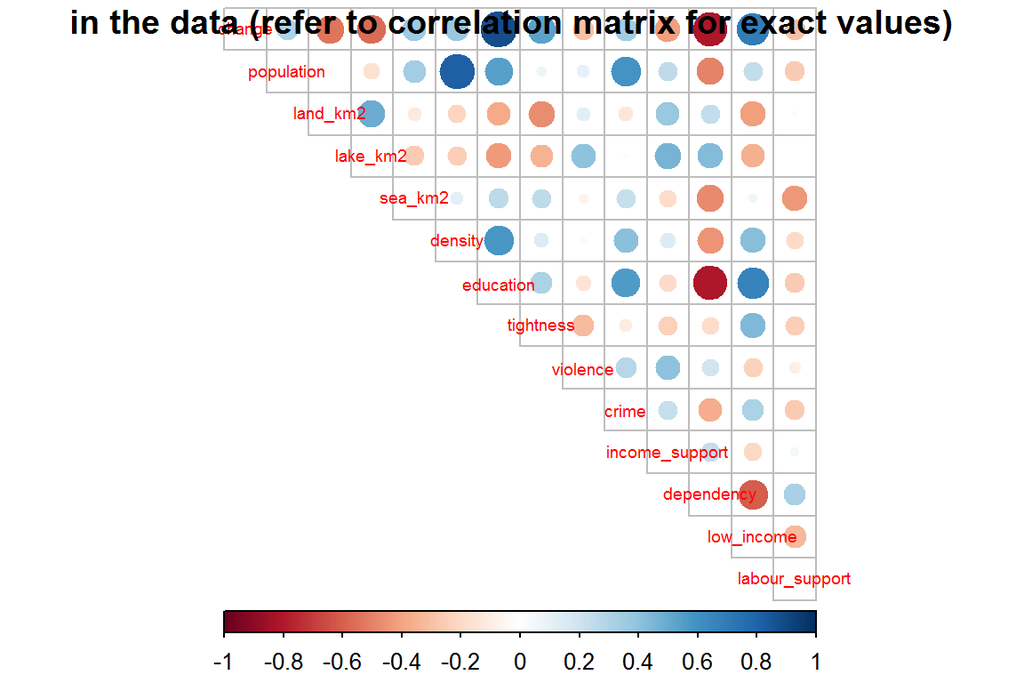

```r
knitr::opts_chunk$set(echo = TRUE, fig.height=15, fig.width=15)

# calculate the correlation matrix and round it
cor_matrix <- cor(selected)  %>% round(digits=2)

# visualize the correlation matrix
corrplot(cor_matrix, method="circle", type ="upper", cl.pos="b", tl.pos="d", tl.cex=0.6, title="Graphical representation of the correlations\nin the data (refer to correlation matrix for exact values)")
```

```r
# print the correlation matrix
cor_matrix
```

```
##                change population land_km2 lake_km2 sea_km2 density
## change           1.00       0.30    -0.54    -0.56    0.36    0.37
## population       0.30       1.00    -0.03    -0.17    0.34    0.81
## land_km2        -0.54      -0.03     1.00     0.49   -0.12   -0.22
## lake_km2        -0.56      -0.17     0.49     1.00   -0.26   -0.25
## sea_km2          0.36       0.34    -0.12    -0.26    1.00    0.11
## density          0.37       0.81    -0.22    -0.25    0.11    1.00
## education        0.88       0.54    -0.38    -0.43    0.26    0.58
## tightness        0.53       0.07    -0.47    -0.35    0.25    0.14
## violence        -0.30       0.10     0.12     0.40   -0.07   -0.03
## crime            0.34       0.59    -0.14    -0.02    0.23    0.41
## income_support  -0.42       0.25     0.37     0.46   -0.19    0.15
## dependency      -0.80      -0.50     0.24     0.43   -0.48   -0.45
## low_income       0.69       0.24    -0.42    -0.36    0.06    0.42
## labour_support  -0.30      -0.26     0.02     0.00   -0.44   -0.20
##                education tightness violence crime income_support
## change              0.88      0.53    -0.30  0.34          -0.42
## population          0.54      0.07     0.10  0.59           0.25
## land_km2           -0.38     -0.47     0.12 -0.14           0.37
## lake_km2           -0.43     -0.35     0.40 -0.02           0.46
## sea_km2             0.26      0.25    -0.07  0.23          -0.19
## density             0.58      0.14    -0.03  0.41           0.15
## education           1.00      0.31    -0.15  0.56          -0.20
## tightness           0.31      1.00    -0.32 -0.11          -0.24
## violence           -0.15     -0.32     1.00  0.28           0.40
## crime               0.56     -0.11     0.28  1.00           0.23
## income_support     -0.20     -0.24     0.40  0.23           1.00
## dependency         -0.80     -0.19     0.19 -0.37           0.24
## low_income          0.66      0.44    -0.23  0.31          -0.21
## labour_support     -0.26     -0.25    -0.09 -0.26           0.05
##                dependency low_income labour_support
## change              -0.80       0.69          -0.30
## population          -0.50       0.24          -0.26
## land_km2             0.24      -0.42           0.02
## lake_km2             0.43      -0.36           0.00
## sea_km2             -0.48       0.06          -0.44
## density             -0.45       0.42          -0.20
## education           -0.80       0.66          -0.26
## tightness           -0.19       0.44          -0.25
## violence             0.19      -0.23          -0.09
## crime               -0.37       0.31          -0.26
## income_support       0.24      -0.21           0.05
## dependency           1.00      -0.61           0.32
## low_income          -0.61       1.00          -0.33
## labour_support       0.32      -0.33           1.00
```

# Modelling

```r
my_model <- lm(change ~ low_income + dependency + education, data = selected)
summary(my_model)
```

```
##
## Call:
## lm(formula = change ~ low_income + dependency + education, data = selected)
##
## Residuals:
##     Min      1Q  Median      3Q     Max
## -32.175  -7.330  -1.883   6.220  37.445
##
## Coefficients:
##              Estimate Std. Error t value Pr(>|t|)
## (Intercept) -45.53291   31.78427  -1.433   0.1609
## low_income    0.11652    0.07288   1.599   0.1189
## dependency   -0.33938    0.17554  -1.933   0.0613 .
## education     0.24459    0.05412   4.520 6.78e-05 ***
## ---
## Signif. codes:  0 '***' 0.001 '**' 0.01 '*' 0.05 '.' 0.1 ' ' 1
##
## Residual standard error: 13.65 on 35 degrees of freedom
## Multiple R-squared:  0.8146, Adjusted R-squared:  0.7987
## F-statistic: 51.26 on 3 and 35 DF,  p-value: 6.805e-13
```

```r
my_model2 <- lm(change ~ education, data = selected)
summary(my_model2)
```

```
##
## Call:
## lm(formula = change ~ education, data = selected)
##
## Residuals:
##     Min      1Q  Median      3Q     Max
## -31.316  -9.705  -2.349   6.365  40.854
##
## Coefficients:
##               Estimate Std. Error t value Pr(>|t|)
## (Intercept) -111.85793   10.49095  -10.66 7.76e-13 ***
## education      0.36721    0.03263   11.25 1.67e-13 ***
## ---
## Signif. codes:  0 '***' 0.001 '**' 0.01 '*' 0.05 '.' 0.1 ' ' 1
##
## Residual standard error: 14.66 on 37 degrees of freedom
## Multiple R-squared:  0.7739, Adjusted R-squared:  0.7678
## F-statistic: 126.6 on 1 and 37 DF,  p-value: 1.671e-13
```

```r
my_model3 <- lm(change ~ ., data = selected)
summary(my_model3)
```

```
##
## Call:
## lm(formula = change ~ ., data = selected)
##
## Residuals:
##      Min       1Q   Median       3Q      Max
## -14.7508  -5.3776   0.5033   5.0706  17.0370
##
## Coefficients:
##                  Estimate Std. Error t value Pr(>|t|)
## (Intercept)    -2.484e+01  2.571e+01  -0.966  0.34337
## population     -1.254e-04  6.558e-05  -1.912  0.06745 .
## land_km2       -1.950e-03  1.242e-03  -1.570  0.12900
## lake_km2       -9.389e-03  1.137e-02  -0.826  0.41674
## sea_km2        -3.445e-03  9.328e-03  -0.369  0.71503
## density        -1.633e-03  2.110e-02  -0.077  0.93890
## education       2.267e-01  4.644e-02   4.881 5.07e-05 ***
## tightness       2.799e+00  7.801e-01   3.588  0.00141 **
## violence       -3.940e-01  7.950e-01  -0.496  0.62452
## crime           2.535e-01  2.457e-01   1.032  0.31212
## income_support -7.405e-02  6.336e-02  -1.169  0.25357
## dependency     -5.348e-01  1.548e-01  -3.456  0.00197 **
## low_income     -6.096e-02  6.208e-02  -0.982  0.33553
## labour_support -3.218e-02  3.806e-02  -0.846  0.40583
## ---
## Signif. codes:  0 '***' 0.001 '**' 0.01 '*' 0.05 '.' 0.1 ' ' 1
##
## Residual standard error: 8.358 on 25 degrees of freedom
## Multiple R-squared:  0.9503, Adjusted R-squared:  0.9245
## F-statistic: 36.79 on 13 and 25 DF,  p-value: 5.049e-13
```

```r
my_model4 <- lm(change ~ education + tightness + dependency + population, data = selected)
summary(my_model4)
```

```
##
## Call:
## lm(formula = change ~ education + tightness + dependency + population,
##     data = selected)
##
## Residuals:
##      Min       1Q   Median       3Q      Max
## -14.6355  -5.4704  -0.7972   6.0908  24.9205
##
## Coefficients:
##               Estimate Std. Error t value Pr(>|t|)
## (Intercept) -5.182e+01  2.021e+01  -2.565 0.014916 *
## education    2.648e-01  3.479e-02   7.611 7.65e-09 ***
## tightness    3.091e+00  5.300e-01   5.833 1.42e-06 ***
## dependency  -5.160e-01  1.109e-01  -4.652 4.84e-05 ***
## population  -1.408e-04  3.272e-05  -4.304 0.000134 ***
## ---
## Signif. codes:  0 '***' 0.001 '**' 0.01 '*' 0.05 '.' 0.1 ' ' 1
##
## Residual standard error: 8.67 on 34 degrees of freedom
## Multiple R-squared:  0.9273, Adjusted R-squared:  0.9187
## F-statistic: 108.4 on 4 and 34 DF,  p-value: < 2.2e-16
```

# Model validation and personal interpretation

Now, I will produce and analyze model dianostic plots (see below). The residuals (prediction errors) seem to follow normal distribution quite well. The errors seem to be tiny bit dependent on the fitted value inside the diminishing municipalities. It raises concern on the generalizability of the model. The obsevations with highest impact (leverage) on the model are Espoo an Luoto. However, their leverage values and Cook’s distances are quite small. Personally, I think that the education as the explanatory variable is the key for understanding the results of this modelling. Young adults search for education and move around Finland to get it. Once they have moved, they will study and establish themselves in the city they chose. They are unlikely to move again, since establising oneself again would break the existing social bonds and require new ones to be build. The moving will also influence the dependency ratio in two ways: the young will find work in the new environment while they are no longer sustaining the dependent in their original home towns. The population will reduce the procentual population change in two ways: little by little the cities get more crowded (increases competition and reduces willingness to move), and the percentual change becomes less dependant on the newcomers as the municipalities grow large enough. Tightness was the most surprising explanatory variable, since increasing it actually increases the growth rate of the municipalities. Maybe this represents the fact that the young moving into cities tend to live in (crowded) student appartments for some initial years of their studies. Then, maybe the social bonds are more effectively formed in the cities where inhabitants (students) live in a tiny bit more crowded way. The current model could be supplemented with age related information to verify the assumptions given. However, that might have to wait for another time.

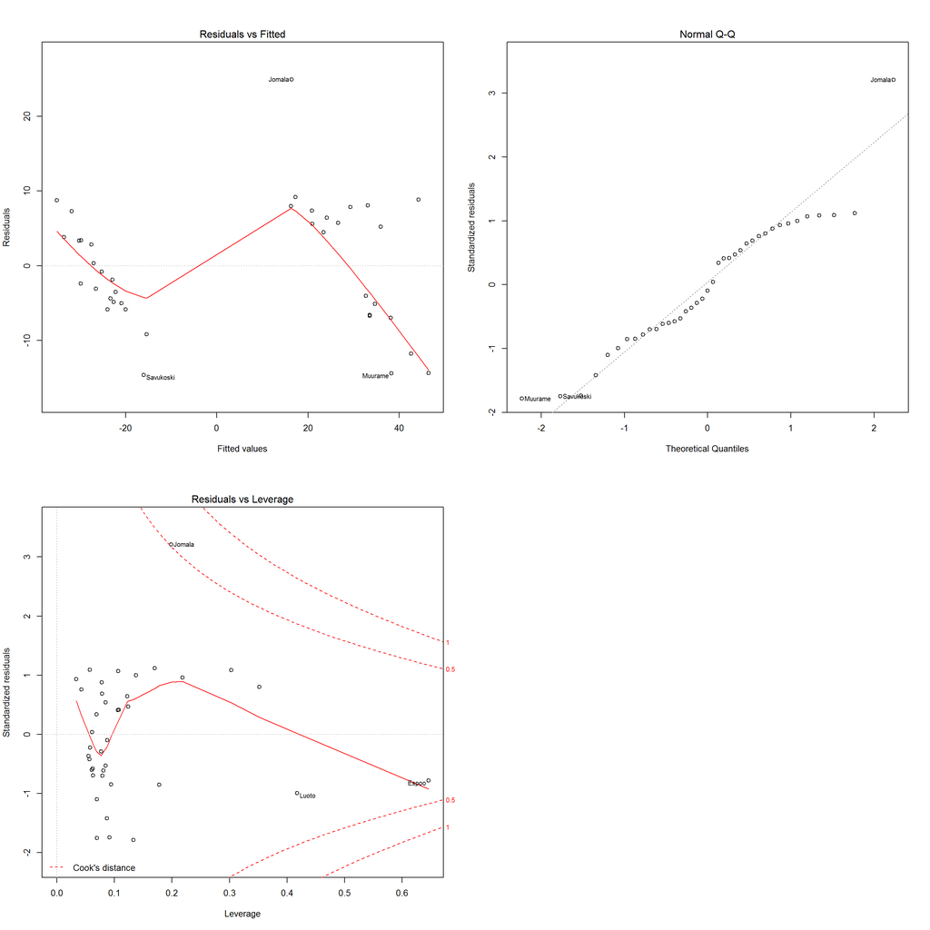

```r
# Plotting the graphical model validation images:
par(mfrow = c(2,2))
plot(my_model4, which = c(1,2,5))
```